# 数据分析与SAS 第四周作业 - 张丹(11)

阅读作业  
1 阅读朱世武的书，学习关于SQL过程的详细用法  
阅读作业由大家自行掌握，不纳入罚扣考核范围

书面作业  
1 尝试在两种不同的数据库（例如在本地的mysql和oracle）之间通过SAS传递数据，数据库的品种任选，数据集自行构建。将实验过程抓图。  
2 读入一些日期值（自行构建数据源），要求以中文日期格式输出（例如”2012年8月21日“），给出源代码，欢迎多种方法尝试

互动作业  
本周的互动继续以SAS编程讨论为主。可以围绕第4周课程有关知识展开。  
要求每位同学至少发2篇主题（SAS中国用户组板块），至少参与5个上述主题的讨论（回帖）。  
注意在Dataguru课程平台上，新增加“互动”功能标签，大家进入后可以看到本周的互动要求（板块，时间段，数量等），以及你现在的完成进度情况。  
本周的书面作业和互动作业都纳入罚扣考核范围，请大家注意按时按质完成！

## 1. 分别连接MySQL, SPSS, EXCEL如图所示

连接MySQL示例：

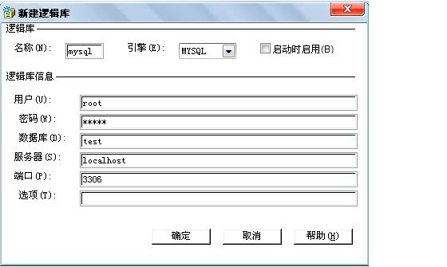

[figure not shown]

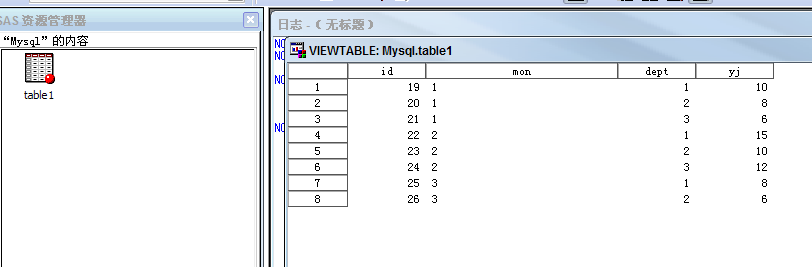

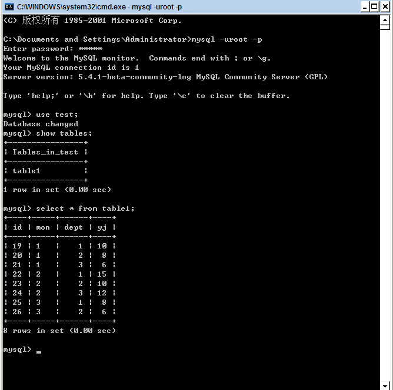

连接SPSS示例：

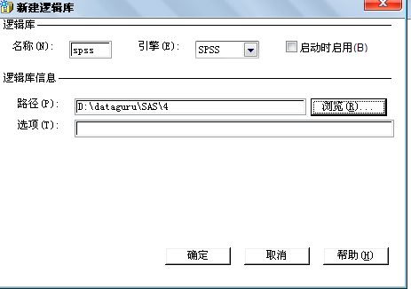

[figure not shown]

[figure not shown]

[figure not shown]

连接EXCEL示例：

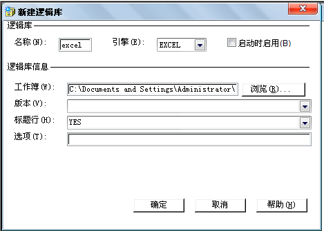

[figure not shown]

[figure not shown]

## 2. 转换日期格式，FORMAT过程picture关键字

[figure not shown]

```sas
libname homework "D:\dataguru\SAS\4";
DATA homework.c1;
  INFORMAT create_date datetime20.;
    INPUT create_date uid @@;
    CARDS;
       08JUN2012:21:11:13  1999321817
       08JUN2012:21:11:18  11250817
       08JUN2012:21:15:14  3299250817
       08JUN2012:21:50:48  259250817
    ;
RUN;

PROC FORMAT ;
    picture dt low-high='%Y年%0m月%0d日 %0H:%0M:%0S'(datatype=datetime);
RUN;

PROC PRINT DATA=homework.c1(KEEP=create_date);
    FORMAT create_date dt.;
RUN;
```